# Hypothesis Testing for Means

Unit 4 Assessment

Author

Ivan Cheng

# Introduction

This assessment is designed as a practice of several analyses we have covered in unit 4. Each example will give background for the research questions.

You are responsible for determining the appropriate alternative hypothesis for each question **based on context**. Unless otherwise specified, use $\alpha = 0.05$.

Do all work **ON YOUR OWN**.

You may use class notes and assignments but not internet searches, Artificial Intelligence or other people.

Don’t forget to load the libraries.

# One-sample Z

There are estimated 234 nesting pairs of bald eagles in Idaho. With a chick survival rate of about 72% and nesting pairs laying 1-3 eggs, the population in Idaho is expected to grow by, on average, 168.48 with a standard deviation of 16.86.

Favorable nesting conditions this year suggest that survival rates should be higher than expected. We randomly select 35 nesting sites and calculate the survival rate to be 82%, meaning we expect population to grow by 187.2.

Test to see if this growth is significantly higher than historical growth.

**QUESTION**: State your null and alternative hypotheses:
$$H_o : u_{Hisgrow} = u_{thisyeargrow}$$
$$H_a : u_{Hisgrow} < u_{Thisyeargrow}$$

Perform the appropriate hypothesis test:

```r
xbar <- 187.2
mu <- 168.48
sigma <- 16.86
n <- 35
sigma_xbar <- sigma / sqrt(n)
sigma_xbar
```

```
[1] 2.84986
```

```r
z <- (xbar - mu)/ sigma_xbar
z
```

```
[1] 6.568743
```

```r
pnorm(z)
```

```
[1] 1
```

```r
1-pnorm(z)
```

```
[1] 2.537082e-11
```

**QUESTION**: What is the the test statistic (z)?  
**ANSWER**: 6.568743

**QUESTION**: State your conclusion:  
**ANSWER**: The possibility to have average population growth by 187.2 is significantly higher than the historical growth.

**QUESTION**: Check the test requirements for a one-sample z-test (can we trust the p-value? Why or why not?): **ANSWER**: Yes, since the sample size is big enough (> 30), the distribution is normally distributed. Thus, we can trust the p-value.

# One-sample t

The label on a protein bar wrapper claims 20 grams of protein. We select a random sample of 31 bars and test to see if there is significantly less protein than advertised.

```r
# Data from (https://www.jmp.com/en_us/statistics-knowledge-portal/t-test/one-sample-t-test.html)

data <- c(20.70, 27.46, 22.15, 19.85, 21.29, 24.75, 20.75, 22.91, 25.34, 20.33, 21.54, 21.08, 22.14, 19.56, 21.10, 18.04, 24.12, 19.95, 19.72, 18.28, 16.26, 17.46, 20.53, 22.12, 25.06, 22.44, 19.08, 19.88, 21.39, 22.33, 25.79)
```

S for sample.

**QUESTION**: State your null and alternative hypotheses:
$$Ho: u_{S} = 20$$
$$Ha: u_{S} < 20$$
$$\alpha = 0.05$$
Perform the appropriate hypothesis test:

```r
favstats(data)
```

```
   min     Q1 median     Q3   max mean       sd  n missing
 16.26 19.865   21.1 22.385 27.46 21.4 2.541669 31       0
```

```r
t.test(data, mu = 20, alternative = "less")
```

```
    One Sample t-test

data:  data
t = 3.0668, df = 30, p-value = 0.9977
alternative hypothesis: true mean is less than 20
95 percent confidence interval:
     -Inf 22.17479
sample estimates:
mean of x
     21.4
```

**QUESTION**: What is the the test statistic (t)?  
**ANSWER**: 3.0668

**QUESTION**: What is the the P-value?  
**ANSWER**: 0.9977

**QUESTION**: Check the requirements for a one-sample t-test (can we trust the p-value? Why or why not?):  
**ANSWER**: Yes, since the sample size is big enough (31 > 30), we can trust the p-value.

Create a 95% confidence interval for the mean protein content:

```r
t.test(data, conf.level = 0.95)$conf.int
```

```
[1] 20.46771 22.33229
attr(,"conf.level")
[1] 0.95
```

**QUESTION**: Interpret the confidence interval in context of the problem:  
**ANSWER**: I’m 95% confident that the true mean of protein ingredient weight of the protein bar is located between 20.46771 and 22.33229.

# 2-sample t: Dependent (Matched Pairs)

An instructor would like to use 2 exams in her classes next year. She hopes they are comparable, meaning as long as they’re not too different from each other, she feels confident using either exam.

Each student took both exams.

```r
# Data and example come from JMP (https://www.jmp.com/en_us/statistics-knowledge-portal/t-test/paired-t-test.html)

exam <- import('https://raw.githubusercontent.com/byuistats/Math221D_Cannon/master/Data/Exam_Comparison.csv')

glimpse(exam)
```

```
Rows: 16
Columns: 4
$ Student        <chr> "Bob", "Nina", "Tim", "Kate", "Alonzo", "Jose", "Nikhil…
$ `Exam 1 Score` <int> 63, 65, 56, 100, 88, 83, 77, 92, 90, 84, 68, 74, 87, 64…
$ `Exam 2 Score` <int> 69, 65, 62, 91, 78, 87, 79, 88, 85, 92, 69, 81, 84, 75,…
$ Comments       <chr> "Data come from JMP Statistical software", "https://www…
```

```r
favstats(exam$`Exam 1 Score`)
```

```
 min    Q1 median Q3 max   mean       sd  n missing
  56 67.25     80 88 100 78.125 12.66425 16       0
```

```r
favstats(exam$`Exam 2 Score`)
```

```
 min   Q1 median   Q3 max    mean       sd  n missing
  62 73.5   81.5 85.5  92 79.4375 9.150364 16       0
```

```r
exam_diff <- exam$`Exam 2 Score` - exam$`Exam 1 Score`
# positive means exam2 score is higher, negative means exam1 score is higher
```

**QUESTION**: State your null and alternative hypotheses:
$$Ho: u_{diff} = 0$$
$$Ha: u_{diff} > 0$$
$$\alpha = 0.05$$
Perform the appropriate hypothesis test:

```r
# positive means exam2 score is higher, negative means exam1 score is higher
t.test(exam_diff, alternative = "greater")
```

```
    One Sample t-test

data:  exam_diff
t = 0.74978, df = 15, p-value = 0.2325
alternative hypothesis: true mean is greater than 0
95 percent confidence interval:
 -1.756251       Inf
sample estimates:
mean of x
   1.3125
```

**QUESTION**: What is the the test statistic (t)?  
**ANSWER**: 0.74978

**QUESTION**: What is the the P-value?  
**ANSWER**: 0.2325

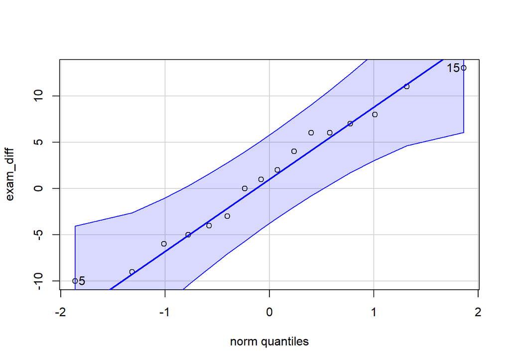

```
[1] 15  5
```

```r
qqPlot(exam_diff)
```

**QUESTION**: Check the requirements for a two-sample, dependent t-test: **ANSWER**: Although both sample numbers aren’t big enough to be assured as normally distributed, the QQPlot graph indicate the exam_diff samples are normally distributed. Thus, we can trust the P-value.

Create a 95% confidence interval for the mean of the differences in test scores:

```r
t.test(exam_diff, conf.level = 0.95)$conf.int
```

```
[1] -2.418647  5.043647
attr(,"conf.level")
[1] 0.95
```

**QUESTION**: Interpret the confidence interval in context of the problem:  
**ANSWER**: I’m 95% confident that the true mean of the difference between exam 1 and exam 2 is located between -2.418647 and 5.043647.

# 2-sample t: Independent

We would like to see if women have a higher body fat percent than men. We randomly select 10 Females and 13 males and collect their body fat percents.

```r
body_fat <- import('https://raw.githubusercontent.com/byuistats/Math221D_Cannon/master/Data/body_fat_percent.csv')

glimpse(body_fat)
```

```
Rows: 23
Columns: 3
$ Gender           <chr> "M", "M", "M", "M", "M", "M", "M", "M", "M", "M", "M"…
$ body_fat_percent <dbl> 13.3, 6.0, 20.0, 8.0, 14.0, 19.0, 18.0, 25.0, 16.0, 2…
$ Comments         <chr> "https://www.jmp.com/en_us/statistics-knowledge-porta…
```

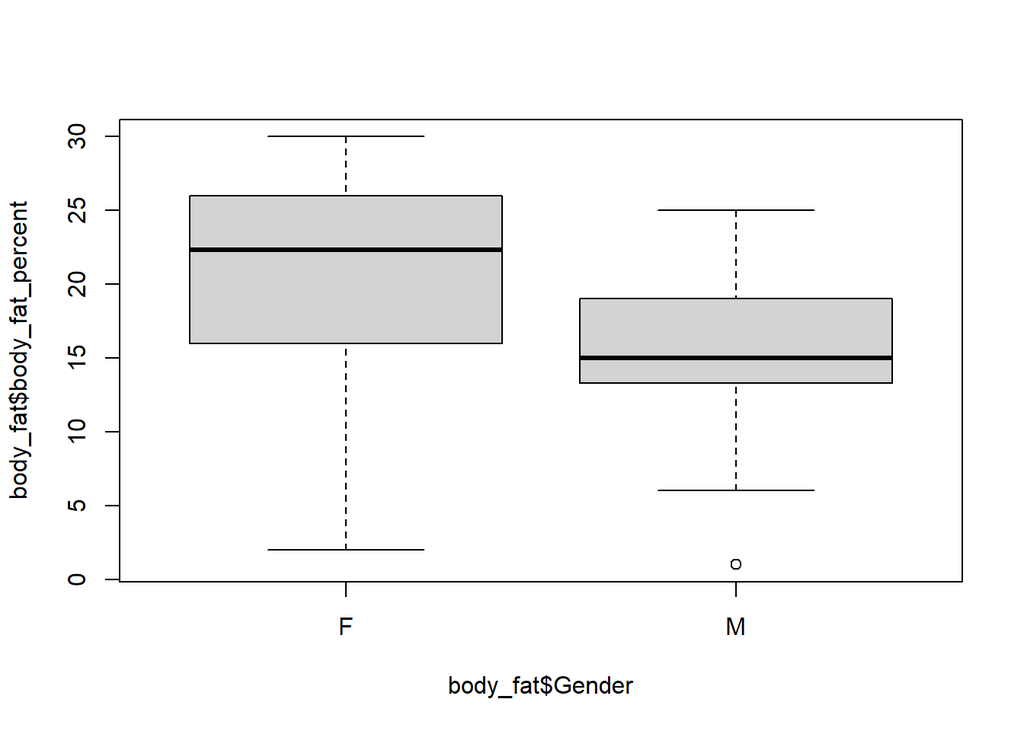

```r
boxplot(body_fat$body_fat_percent ~ body_fat$Gender)
```

**QUESTION**: State your null and alternative hypotheses:
$$Ho: u_{F} = u_{M}$$
$$Ha: u_{F} > u_{M}$$
$$\alpha = 0.05$$
Perform the appropriate hypothesis test:

```r
t.test(body_fat$body_fat_percent ~ body_fat$Gender, alternative = "greater")
```

```
    Welch Two Sample t-test

data:  body_fat$body_fat_percent by body_fat$Gender
t = 1.6444, df = 17.26, p-value = 0.05909
alternative hypothesis: true difference in means between group F and group M is greater than 0
95 percent confidence interval:
 -0.3044232        Inf
sample estimates:
mean in group F mean in group M
       20.29000        14.94615
```

```r
# Although sometimes the outcome of data seems weird, finish all and let the numbers talk to you. Listen to the stats first and see why it states as it is.
```

**QUESTION**: What is the the test statistic (t)?  
**ANSWER**: 1.6444

**QUESTION**: What is the the P-value?  
**ANSWER**: 0.05909 (bigger than our alpha value 0.05)

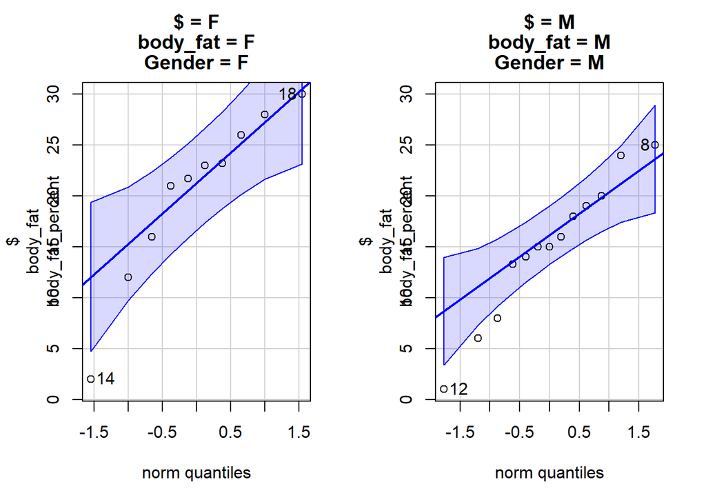

```r
qqPlot(body_fat$body_fat_percent ~ body_fat$Gender)
```

```r
t.test(body_fat$body_fat_percent ~ body_fat$Gender, conf.level = 0.95)$conf.int
```

```
[1] -1.504523 12.192215
attr(,"conf.level")
[1] 0.95
```

**QUESTION**: Interpret the confidence interval in context of the problem:  
**ANSWER**: I’m 95% confident that the real mean difference of body fat between female and male is located between -1.504523 and 12.192215.

# ANOVA

A manufacturer has received complaints that an adhesive’s efficacy is variable. Viscosity of an adhesive is related to it’s effectiveness. You decide to randomly select 5 bottles of adhesive from 5 different production batches and see if there are differences between the batches (called lots in the data.)

```r
# Example and data come from the JMP statistical software website
# https://www.jmp.com/en_us/statistics-knowledge-portal/one-way-anova.html


viscosity <- import('https://raw.githubusercontent.com/byuistats/Math221D_Cannon/master/Data/Viscosity_anova.csv')

glimpse(viscosity)
```

```
Rows: 25
Columns: 3
$ Lot       <chr> "A", "A", "A", "A", "A", "B", "B", "B", "B", "B", "C", "C", …
$ Viscosity <dbl> 29.39, 31.51, 30.88, 27.63, 28.85, 30.63, 32.10, 30.11, 29.6…
$ Comments  <chr> "Data and example come from JMP statsitical software website…
```

```r
unique(viscosity$Lot)
```

```
[1] "A" "B" "C" "D" "E"
```

```r
# Lot: A-E
```

**QUESTION**: State your null and alternative hypotheses:
$$Ho: u_A = u_B = u_C = u_D = u_E$$
$$Ha: At\ least\ one\ of\ them\ not\ equals\ to\ one\ another$$

Perform the appropriate hypothesis test:

```r
aov_viscosity <- aov(viscosity$Viscosity ~ viscosity$Lot)

summary(aov_viscosity)
```

```
              Df Sum Sq Mean Sq F value  Pr(>F)
viscosity$Lot  4  45.26   11.31   6.899 0.00117 **
Residuals     20  32.80    1.64
---
Signif. codes:  0 '***' 0.001 '**' 0.01 '*' 0.05 '.' 0.1 ' ' 1
```

**QUESTION**: What is the the test statistic (F)?  
**ANSWER**: 6.899

**QUESTION**: What is the the P-value?  
**ANSWER**: 0.00117

**QUESTION**: State your conclusion:  
**ANSWER**: I have sufficient evidence to suggest that the mean viscosity score between lot A to lot E not all equal to each other.

```r
sds = favstats(viscosity$Viscosity ~ viscosity$Lot)$sd

max(sds)/ min(sds)
```

```
[1] 1.875618
```

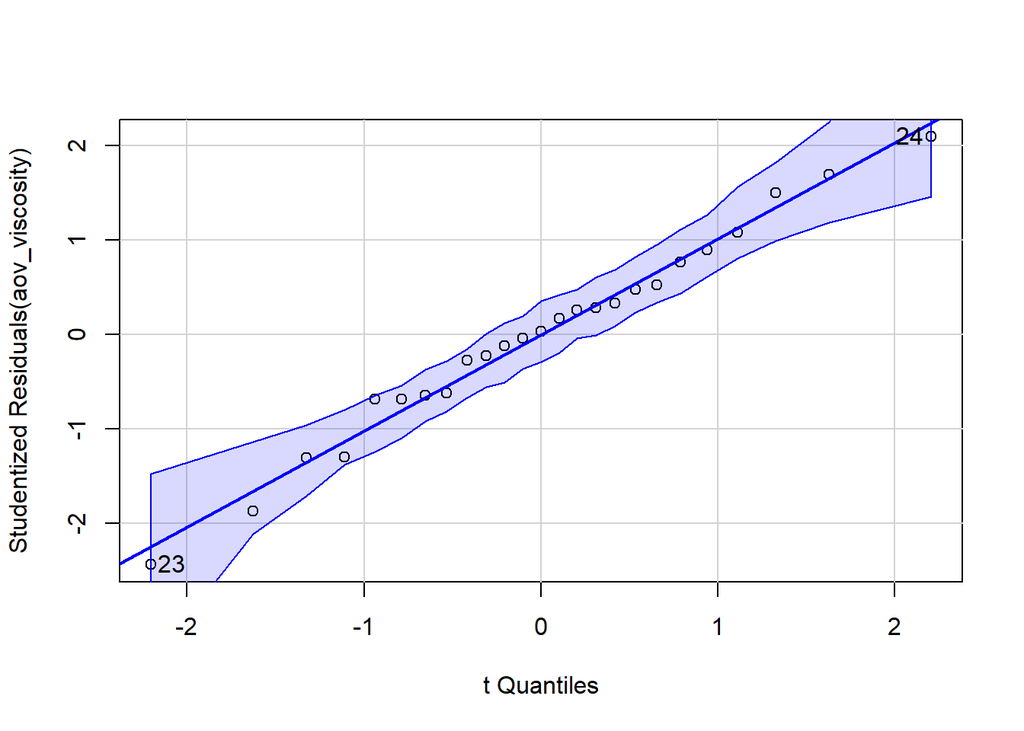

```
[1] 23 24
```

```r
qqPlot(aov_viscosity)
```

**QUESTION**: Check the requirements for ANOVA (Can we trust the p-value? Why or why not?):  
**ANSWER**: Yes we can trust the p-value since both the equal standard deviation test (ratio between max sd and min sd < 2) and qqPlot show the aov distributions are normally distributed.

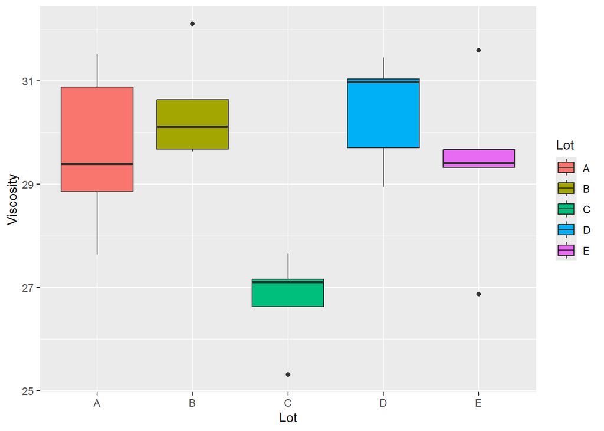

```r
ggplot(data = viscosity, mapping = aes(x = Lot, y = Viscosity, fill = Lot)) +
  geom_boxplot()
```

Create a side-by-side boxplot **using GGPlot** looking at viscosity for each lot.

**QUESTION**: Based on the boxplot, can you make any reasonable inferences beyond the ANOVA hypothesis test conclusion?  
**ANSWER**: Because the viscosity score distribution of Lot C is far lower from the other 4 Lots, that’s why the possibility that they have the same mean so low.